# YOU_TUBE_DATA_SET_FOR_EDA_ANALYSIS

```python
# Importing the all required libraries:-
import pandas as pd
import numpy as np
import seaborn as sns
import matplotlib.pyplot as plt
import datetime
```

# 1. Import required libraries and read the provided dataset (youtube_dislike_dataset.csv) and retrieve top 5 and bottom 5 records.

```python
# Reading the (Youtube_dislike_dataset.csv)
you_tube= pd.read_csv("youtube_dislike_dataset.csv")
```

```python
# creating the same copy of the you_tube data to work with and the variable name as df
df = you_tube.copy()
```

```python
# Retriving the Top 5 from the record:-
df.head(5)
```

|  | video_id | title | channel_id | channel_title | published_at | view_count | likes | dislikes | comment_count | tags | description | comments |
| --- | --- | --- | --- | --- | --- | --- | --- | --- | --- | --- | --- | --- |
| 0 | --0bCF-iK2E | Jadon Sancho Magical Skills & Goals | UC6UL29enLNe4mqwTfAyeNuw | Bundesliga | 2021-07-01 10:00:00 | 1048888 | 19515 | 226 | 1319 | football soccer ftbol alemn Bundesliga season ... | Enjoy the best skills and goals from Jadon San... | Respect to Dortmund fans,must be sad losing hi... |
| 1 | --14w5SOEUs | Migos - Avalanche (Official Video) | UCGIelM2Dj3zza3xyV3pL3WQ | MigosVEVO | 2021-06-10 16:00:00 | 15352638 | 359277 | 7479 | 18729 | Migos Avalanche Quality Control Music/Motown R... | Watch the the official video for Migos - "Aval... | Migos just makes me want to live my live to th... |
| 2 | --40TEbZ9Is | Supporting Actress in a Comedy: 73rd Emmys | UClBKH8yZRcM4AsRjDVEdjMg | Television Academy | 2021-09-20 01:03:32 | 925281 | 11212 | 401 | 831 |  | Hannah Waddingham wins the Emmy for Supporting... | Hannah's energy bursts through any screen. Wel... |
| 3 | --4tfbSyYDE | JO1'YOUNG (JO1 ver.)' PERFORMANCE VIDEO | UCsmXiDP8S40uBeJYxvyulmA | JO1 | 2021-03-03 10:00:17 | 2641597 | 39131 | 441 | 3745 | PRODUCE101JAPAN JO1 TheSTAR STA... | JO1'YOUNG (JO1 ver.)' PERFORMANCE VIDEO\n\n---... | youngVer>< REN is really PERFECT. It's not ju... |
| 4 | --DKkzWVh-E | Why Retaining Walls Collapse | UCMOqf8ab-42UUQIdVoKwjlQ | Practical Engineering | 2021-12-07 13:00:00 | 715724 | 32887 | 367 | 1067 | retaining wall New Jersey highway Direct Conne... | One of the most important (and innocuous) part... | Keep up with all my projects here: https://pr... |

```python
# Retriving the bottom 5 from the records:-
df.tail(5)
```

|  | video_id | title | channel_id | channel_title | published_at | view_count | likes | dislikes | comment_count | tags | description | comments |
| --- | --- | --- | --- | --- | --- | --- | --- | --- | --- | --- | --- | --- |
| 37417 | zzd4ydafGR0 | Lil Tjay - Calling My Phone (feat. 6LACK) [Off... | UCEB4a5o_6KfjxHwNMnmj54Q | Lil Tjay | 2021-02-12 05:03:49 | 120408275 | 2180780 | 35871 | 81360 | Lil Tjay Steady Calling My Phone Calling My Ph... | Official video for "Calling My Phone" by Lil T... | 'DESTINED 2 WIN' OUT NOW !! https://liltjay.ln... |
| 37418 | zziBybeSAtw | PELICANS at LAKERS \| FULL GAME HIGHLIGHTS \| Ja... | UCWJ2lWNubArHWmf3FIHbfcQ | NBA | 2021-01-16 05:39:05 | 2841917 | 20759 | 1049 | 2624 | NBA G League Basketball game-0022000187 Lakers... | PELICANS at LAKERS \| FULL GAME HIGHLIGHTS \| Ja... | Montrezl Harrell is going crazy with the rebou... |
| 37419 | zzk09ESX7e0 | [MV] (MAMAMOO) - Where Are We Now | UCuhAUMLzJxlP1W7mEk0_6lA | MAMAMOO | 2021-06-02 09:00:10 | 13346678 | 720854 | 4426 | 90616 | MAMAMOO WAW WAW MAMAMOO WAW Where Are We Now... | [MV] (MAMAMOO) - Where Are We Now\n\nInstagra... | I honestly do not know why this song hit so ha... |
| 37420 | zzmQEb0Em5I | FELLIPE ESCUDERO- Master Podcast #12 | UC8NjnNWMsRqq11NYvHAQb1g | Master Podcast | 2020-10-20 20:59:30 | 252057 | 19198 | 1234 | 1471 | master masterpodcast lord lord vinheteiro z z ... | DOCTOR HAIR\nhttps://www.thedoctorhair.com/?fb... | Foi um prazer passar esta tarde com vocs debat... |
| 37421 | zzxPZwaA-8w | Gareth Bale brace secures dramatic comeback on... | UCEg25rdRZXg32iwai6N6l0w | Tottenham Hotspur | 2021-05-23 21:00:31 | 2252090 | 34063 | 868 | 2004 | Spurs Tottenham Hotspur Tottenham Leicester ... | Two minute highlights from Tottenham Hotspur's... | Thank you Kane for everything you have given t... |

# 2. Check the info of the dataframe and write your inferences on data types and shape of the dataset

```python
# Checking the info of the Dataframe:-
df.info()
```

```
<class 'pandas.core.frame.DataFrame'>
RangeIndex: 37422 entries, 0 to 37421
Data columns (total 12 columns):
 #   Column         Non-Null Count  Dtype
---  ------         --------------  -----
 0   video_id       37422 non-null  object
 1   title          37422 non-null  object
 2   channel_id     37422 non-null  object
 3   channel_title  37422 non-null  object
 4   published_at   37422 non-null  object
 5   view_count     37422 non-null  int64
 6   likes          37422 non-null  int64
 7   dislikes       37422 non-null  int64
 8   comment_count  37422 non-null  int64
 9   tags           37422 non-null  object
 10  description    37422 non-null  object
 11  comments       37264 non-null  object
dtypes: int64(4), object(8)
memory usage: 3.4+ MB
```

# Inference:-

##### Since we have to read this data in pandas it converted into DataFrame,

##### This Data set holds a rangeindex of 37422 entries which is starting form 0.

#### Holds 12 columns int64(4 columns), object(8 columns)

#### Total memory usage of this data set was 3.4+ MB.

```python
# Checking the shape of the df record:-
df.shape
```

```
(37422, 12)
```

#### It is having the 37422 rows and 12 columns

```python
# Checking the Datatype of the record:-
df.dtypes
```

```
video_id         object
title            object
channel_id       object
channel_title    object
published_at     object
view_count        int64
likes             int64
dislikes          int64
comment_count     int64
tags             object
description      object
comments         object
dtype: object
```

#### This holds Datatype of both int and Object

#### The columns which hold (int 64) as its datatype are(view_count,likes,dislikes,comment_count)

#### The columns which hold (object) as its datatype are(video_id,title,channel_id,channel_title,published_at,tags,description,comments

# 3. Check for the Percentage of the missing values and drop or impute them.

```python
# Checking the null values in all columns:- by using (.isnull) and (.sum()) to get the overall null values presence in all columns:-
df.isnull().sum()
```

```
video_id           0
title              0
channel_id         0
channel_title      0
published_at       0
view_count         0
likes              0
dislikes           0
comment_count      0
tags               0
description        0
comments         158
dtype: int64
```

#### comments in dataset holds about 158 null values

```python
# Checking the comments and showing the null values:-
df[df["comments"].isnull()]
```

|  | video_id | title | channel_id | channel_title | published_at | view_count | likes | dislikes | comment_count | tags | description | comments |
| --- | --- | --- | --- | --- | --- | --- | --- | --- | --- | --- | --- | --- |
| 344 | -bZxO5Dn9x0 | LEGO Star Wars Holiday Special \| Official Trai... | UCZGYJFUizSax-yElQaFDp5Q | Star Wars | 2020-11-05 14:00:43 | 1236365 | 44348 | 2259 | 0 |  | The LEGO Star Wars Holiday Special reunites Re... | NaN |
| 418 | -jdVyvuFC0A | The National Lottery Lotto' draw results from ... | UCnOiv4Hp3fu43NDHl335cvQ | The National Lottery | 2021-05-12 19:04:37 | 83155 | 184 | 39 | 0 | Lotto National Lottery The National Lottery Lo... | The National Lottery draw results for Lotto re... | NaN |
| 477 | -qTCT6nLbWo | The National Lottery Lotto' draw results from ... | UCnOiv4Hp3fu43NDHl335cvQ | The National Lottery | 2021-01-30 19:48:30 | 135946 | 263 | 138 | 0 | Lotto National Lottery The National Lottery Lo... | The National Lottery draw results for Lotto re... | NaN |
| 720 | 0IE1TVLH7eI | Amoureuse | UCntsZ2Irpt7Nc_-tNJmCtmA | Yanns - Topic | 2021-09-02 10:01:23 | 2177257 | 21450 | 722 | 0 | Yanns Noodels Marco Bressan Yannick Schweitzer... | Provided to YouTube by Believe SAS\n\nAmoureus... | NaN |
| 727 | 0JFhV5sBUYo | Meu Corao Me Odeia | UCJltSNle2RK9jtOUuSdREZw | Taty Girl - Topic | 2021-08-12 10:02:02 | 280350 | 3153 | 133 | 0 | Taty Girl Wesley Safado Meu Corao Me Odeia | Provided to YouTube by Potencia Music\n\nMeu C... | NaN |
| ... | ... | ... | ... | ... | ... | ... | ... | ... | ... | ... | ... | ... |
| 35720 | x7WtabxoTdQ | :BTSFilm out 90202142 | UCTDMT3aL30noTVFgNPA9XtQ | MOVIE | 2021-02-15 19:00:12 | 2275095 | 96958 | 552 | 0 | STUDIO DRAGON ASTORY BTS... | 90\nBTSFilm out\nback number\n\nFilm outback ... | NaN |
| 36335 | yBfamIFpucw | A QUEDA | UCCt8cGO1NfZgi0XO_kbsesw | Gloria Groove - Topic | 2021-10-15 00:01:42 | 4890598 | 119549 | 5154 | 0 | Gloria Groove Lukinhas Pablo Bispo Ruxell A QUEDA | Provided to YouTube by The Orchard Enterprises... | NaN |
| 36669 | yiWErhQbUho | Hanuman Chalisa I GULSHAN KUMAR I HARIHARAN,... | UCaayLD9i5x4MmIoVZxXSv_g | T-Series Bhakti Sagar | 2021-01-05 00:30:03 | 446713 | 8561 | 1047 | 857 | Hanuman Chalisa Hanuman Chalisa Gulshan Kumar ... | SUBSCRIBE:http://www.youtube.com/tseriesbhakti... | NaN |
| 36701 | ylPCxAwqTLk | . 2 - 2D \| \| 2021! | UC5A-Wp9ujcr5g9sYagAafEA | TVSmeshariki | 2021-08-06 11:59:34 | 693473 | 8237 | 783 | 0 | 2 2d 2d ... | : . , . , . , - . , ... | NaN |
| 36981 | zCkfx65Vjw4 | . Broken Vow - - . - 8 | UCXBIIbGe37lKXFHdM050f2w | The Voice Kids Russia/ | 2021-02-12 20:37:11 | 665998 | 15913 | 225 | 0 | the voice kids 7 7 ... | Broken Vow. Lara Fabian 1999 . ... | NaN |

158 rows × 12 columns

```python
# Checking the percentage of null values contribution to the overall dataset:-
df.isnull().sum()*100/len(df)
# so,the comments columns holds null value of 0.4222%
```

```
video_id         0.000000
title            0.000000
channel_id       0.000000
channel_title    0.000000
published_at     0.000000
view_count       0.000000
likes            0.000000
dislikes         0.000000
comment_count    0.000000
tags             0.000000
description      0.000000
comments         0.422212
dtype: float64
```

#### so,the comments columns holds null value of 0.4222%

```python
# Dropping the null values:-
df.dropna(inplace=True)
```

```python
# Checking again for null values after dropping:- (and also assigning)
df.isnull().sum()
```

```
video_id         0
title            0
channel_id       0
channel_title    0
published_at     0
view_count       0
likes            0
dislikes         0
comment_count    0
tags             0
description      0
comments         0
dtype: int64
```

# 4. Check the statistical summary of both numerical and categorical columns and write your inferences.

```python
# describing the data of numerical columns:- by using .describe() function
df.describe()
# The Below DataFrame table shows the above mentioned described functions with values:-
```

|  | view_count | likes | dislikes | comment_count |
| --- | --- | --- | --- | --- |
| count | 3.726400e+04 | 3.726400e+04 | 3.726400e+04 | 3.726400e+04 |
| mean | 5.710821e+06 | 1.672867e+05 | 4.996434e+03 | 9.966953e+03 |
| std | 2.431304e+07 | 5.384931e+05 | 3.075194e+04 | 1.173465e+05 |
| min | 2.036800e+04 | 2.200000e+01 | 3.000000e+00 | 1.000000e+00 |
| 25% | 5.141305e+05 | 1.331725e+04 | 2.827500e+02 | 9.140000e+02 |
| 50% | 1.321860e+06 | 4.255600e+04 | 7.980000e+02 | 2.347000e+03 |
| 75% | 3.674527e+06 | 1.309665e+05 | 2.466250e+03 | 6.212000e+03 |
| max | 1.322797e+09 | 3.183768e+07 | 2.397733e+06 | 1.607103e+07 |

#### The numerical columns were view_count, likes, dislikes, comment_count

#### count determines the count of non-missing values

#### mean determines the average of each numerical column

#### std determines the spread of data around the mean

#### min determines the minimum value of the data

#### 25%,50%,75%, determines the percentile values of data column

#### max detemines the max value of each numerical column

```python
# Including the objects of categorical column:-
df.describe(include="object")
# The Below DataFrame table shows the above mentioned described with values:-
```

|  | video_id | title | channel_id | channel_title | published_at | tags | description | comments |
| --- | --- | --- | --- | --- | --- | --- | --- | --- |
| count | 37264 | 37264 | 37264 | 37264 | 37264 | 37264 | 37264 | 37264 |
| unique | 37264 | 36958 | 10891 | 10813 | 36617 | 28705 | 35479 | 37264 |
| top | --0bCF-iK2E | www | UCNAf1k0yIjyGu3k9BwAg3lg | Sky Sports Football | 2020-10-16 04:00:10 |  |  | Respect to Dortmund fans,must be sad losing hi... |
| freq | 1 | 21 | 533 | 533 | 6 | 3808 | 587 | 1 |

#### count determines the number of non-missing values in each Categorical columns

#### unique determines the number of unique categories in each Categorical columns

#### top determines the most frequent category in each categorical columns

#### freq determines the most frequency of most frequent category

## Inference

### It shows that it has maximum view_count of 1Billion

### Max likes of 31 Million and dislikes of 2 Million

### The max frequency of channel was about 533

# 5. Convert datatype of column published_at from object to pandas datetime

```python
# Datatype before conversion it was object need to convert it completely to datetime:-
df["published_at"]
```

```
0        2021-07-01 10:00:00
1        2021-06-10 16:00:00
2        2021-09-20 01:03:32
3        2021-03-03 10:00:17
4        2021-12-07 13:00:00
                ...
37417    2021-02-12 05:03:49
37418    2021-01-16 05:39:05
37419    2021-06-02 09:00:10
37420    2020-10-20 20:59:30
37421    2021-05-23 21:00:31
Name: published_at, Length: 37264, dtype: object
```

```python
# To convert using pd.to_datetime() function and assigning the same:-
df["published_at"] = pd.to_datetime(df["published_at"])
```

```python
# checking the column and its data type:-
df["published_at"]
# Showing the results as datatime64[ns]
```

```
0       2021-07-01 10:00:00
1       2021-06-10 16:00:00
2       2021-09-20 01:03:32
3       2021-03-03 10:00:17
4       2021-12-07 13:00:00
                ...
37417   2021-02-12 05:03:49
37418   2021-01-16 05:39:05
37419   2021-06-02 09:00:10
37420   2020-10-20 20:59:30
37421   2021-05-23 21:00:31
Name: published_at, Length: 37264, dtype: datetime64[ns]
```

# 6. Create a new column as 'published_month' using the column published_at (display the months only)

```python
# Now creating the new column as published_month to the dataset by displaying the months only:-
```

```python
df["published_month"] = df["published_at"].dt.month
```

```python
# The created new column is added to the data set and month is displayed to it.
df
```

|  | video_id | title | channel_id | channel_title | published_at | view_count | likes | dislikes | comment_count | tags | description | comments | published_month |
| --- | --- | --- | --- | --- | --- | --- | --- | --- | --- | --- | --- | --- | --- |
| 0 | --0bCF-iK2E | Jadon Sancho Magical Skills & Goals | UC6UL29enLNe4mqwTfAyeNuw | Bundesliga | 2021-07-01 10:00:00 | 1048888 | 19515 | 226 | 1319 | football soccer ftbol alemn Bundesliga season ... | Enjoy the best skills and goals from Jadon San... | Respect to Dortmund fans,must be sad losing hi... | 7 |
| 1 | --14w5SOEUs | Migos - Avalanche (Official Video) | UCGIelM2Dj3zza3xyV3pL3WQ | MigosVEVO | 2021-06-10 16:00:00 | 15352638 | 359277 | 7479 | 18729 | Migos Avalanche Quality Control Music/Motown R... | Watch the the official video for Migos - "Aval... | Migos just makes me want to live my live to th... | 6 |
| 2 | --40TEbZ9Is | Supporting Actress in a Comedy: 73rd Emmys | UClBKH8yZRcM4AsRjDVEdjMg | Television Academy | 2021-09-20 01:03:32 | 925281 | 11212 | 401 | 831 |  | Hannah Waddingham wins the Emmy for Supporting... | Hannah's energy bursts through any screen. Wel... | 9 |
| 3 | --4tfbSyYDE | JO1'YOUNG (JO1 ver.)' PERFORMANCE VIDEO | UCsmXiDP8S40uBeJYxvyulmA | JO1 | 2021-03-03 10:00:17 | 2641597 | 39131 | 441 | 3745 | PRODUCE101JAPAN JO1 TheSTAR STA... | JO1'YOUNG (JO1 ver.)' PERFORMANCE VIDEO\n\n---... | youngVer>< REN is really PERFECT. It's not ju... | 3 |
| 4 | --DKkzWVh-E | Why Retaining Walls Collapse | UCMOqf8ab-42UUQIdVoKwjlQ | Practical Engineering | 2021-12-07 13:00:00 | 715724 | 32887 | 367 | 1067 | retaining wall New Jersey highway Direct Conne... | One of the most important (and innocuous) part... | Keep up with all my projects here: https://pr... | 12 |
| ... | ... | ... | ... | ... | ... | ... | ... | ... | ... | ... | ... | ... | ... |
| 37417 | zzd4ydafGR0 | Lil Tjay - Calling My Phone (feat. 6LACK) [Off... | UCEB4a5o_6KfjxHwNMnmj54Q | Lil Tjay | 2021-02-12 05:03:49 | 120408275 | 2180780 | 35871 | 81360 | Lil Tjay Steady Calling My Phone Calling My Ph... | Official video for "Calling My Phone" by Lil T... | 'DESTINED 2 WIN' OUT NOW !! https://liltjay.ln... | 2 |
| 37418 | zziBybeSAtw | PELICANS at LAKERS \| FULL GAME HIGHLIGHTS \| Ja... | UCWJ2lWNubArHWmf3FIHbfcQ | NBA | 2021-01-16 05:39:05 | 2841917 | 20759 | 1049 | 2624 | NBA G League Basketball game-0022000187 Lakers... | PELICANS at LAKERS \| FULL GAME HIGHLIGHTS \| Ja... | Montrezl Harrell is going crazy with the rebou... | 1 |
| 37419 | zzk09ESX7e0 | [MV] (MAMAMOO) - Where Are We Now | UCuhAUMLzJxlP1W7mEk0_6lA | MAMAMOO | 2021-06-02 09:00:10 | 13346678 | 720854 | 4426 | 90616 | MAMAMOO WAW WAW MAMAMOO WAW Where Are We Now... | [MV] (MAMAMOO) - Where Are We Now\n\nInstagra... | I honestly do not know why this song hit so ha... | 6 |
| 37420 | zzmQEb0Em5I | FELLIPE ESCUDERO- Master Podcast #12 | UC8NjnNWMsRqq11NYvHAQb1g | Master Podcast | 2020-10-20 20:59:30 | 252057 | 19198 | 1234 | 1471 | master masterpodcast lord lord vinheteiro z z ... | DOCTOR HAIR\nhttps://www.thedoctorhair.com/?fb... | Foi um prazer passar esta tarde com vocs debat... | 10 |
| 37421 | zzxPZwaA-8w | Gareth Bale brace secures dramatic comeback on... | UCEg25rdRZXg32iwai6N6l0w | Tottenham Hotspur | 2021-05-23 21:00:31 | 2252090 | 34063 | 868 | 2004 | Spurs Tottenham Hotspur Tottenham Leicester ... | Two minute highlights from Tottenham Hotspur's... | Thank you Kane for everything you have given t... | 5 |

37264 rows × 13 columns

# 7. Replace the numbers in the column published_month as names of the months i,e., 1 as 'Jan', 2 as 'Feb' and so on.....

```python
# To assign the values of month as names as per requirement, the first step is to create the dict of month as values and numbers as keys
month_names = {1:"Jan",2:"Feb",3:"Mar",4:"Apr",5:"May",6:"Jun",7:"Jul",8:"Aug",9:"Sep",10:"Oct",11:"Nov",12:"Dec"}
```

```python
# By using the map function we can assign the month names as per requirement
df["published_month"] = df["published_month"].map(month_names)
```

```python
# checking the df, and the month assigned to the data frame successfully:-
df
```

|  | video_id | title | channel_id | channel_title | published_at | view_count | likes | dislikes | comment_count | tags | description | comments | published_month |
| --- | --- | --- | --- | --- | --- | --- | --- | --- | --- | --- | --- | --- | --- |
| 0 | --0bCF-iK2E | Jadon Sancho Magical Skills & Goals | UC6UL29enLNe4mqwTfAyeNuw | Bundesliga | 2021-07-01 10:00:00 | 1048888 | 19515 | 226 | 1319 | football soccer ftbol alemn Bundesliga season ... | Enjoy the best skills and goals from Jadon San... | Respect to Dortmund fans,must be sad losing hi... | Jul |
| 1 | --14w5SOEUs | Migos - Avalanche (Official Video) | UCGIelM2Dj3zza3xyV3pL3WQ | MigosVEVO | 2021-06-10 16:00:00 | 15352638 | 359277 | 7479 | 18729 | Migos Avalanche Quality Control Music/Motown R... | Watch the the official video for Migos - "Aval... | Migos just makes me want to live my live to th... | Jun |
| 2 | --40TEbZ9Is | Supporting Actress in a Comedy: 73rd Emmys | UClBKH8yZRcM4AsRjDVEdjMg | Television Academy | 2021-09-20 01:03:32 | 925281 | 11212 | 401 | 831 |  | Hannah Waddingham wins the Emmy for Supporting... | Hannah's energy bursts through any screen. Wel... | Sep |
| 3 | --4tfbSyYDE | JO1'YOUNG (JO1 ver.)' PERFORMANCE VIDEO | UCsmXiDP8S40uBeJYxvyulmA | JO1 | 2021-03-03 10:00:17 | 2641597 | 39131 | 441 | 3745 | PRODUCE101JAPAN JO1 TheSTAR STA... | JO1'YOUNG (JO1 ver.)' PERFORMANCE VIDEO\n\n---... | youngVer>< REN is really PERFECT. It's not ju... | Mar |
| 4 | --DKkzWVh-E | Why Retaining Walls Collapse | UCMOqf8ab-42UUQIdVoKwjlQ | Practical Engineering | 2021-12-07 13:00:00 | 715724 | 32887 | 367 | 1067 | retaining wall New Jersey highway Direct Conne... | One of the most important (and innocuous) part... | Keep up with all my projects here: https://pr... | Dec |
| ... | ... | ... | ... | ... | ... | ... | ... | ... | ... | ... | ... | ... | ... |
| 37417 | zzd4ydafGR0 | Lil Tjay - Calling My Phone (feat. 6LACK) [Off... | UCEB4a5o_6KfjxHwNMnmj54Q | Lil Tjay | 2021-02-12 05:03:49 | 120408275 | 2180780 | 35871 | 81360 | Lil Tjay Steady Calling My Phone Calling My Ph... | Official video for "Calling My Phone" by Lil T... | 'DESTINED 2 WIN' OUT NOW !! https://liltjay.ln... | Feb |
| 37418 | zziBybeSAtw | PELICANS at LAKERS \| FULL GAME HIGHLIGHTS \| Ja... | UCWJ2lWNubArHWmf3FIHbfcQ | NBA | 2021-01-16 05:39:05 | 2841917 | 20759 | 1049 | 2624 | NBA G League Basketball game-0022000187 Lakers... | PELICANS at LAKERS \| FULL GAME HIGHLIGHTS \| Ja... | Montrezl Harrell is going crazy with the rebou... | Jan |
| 37419 | zzk09ESX7e0 | [MV] (MAMAMOO) - Where Are We Now | UCuhAUMLzJxlP1W7mEk0_6lA | MAMAMOO | 2021-06-02 09:00:10 | 13346678 | 720854 | 4426 | 90616 | MAMAMOO WAW WAW MAMAMOO WAW Where Are We Now... | [MV] (MAMAMOO) - Where Are We Now\n\nInstagra... | I honestly do not know why this song hit so ha... | Jun |
| 37420 | zzmQEb0Em5I | FELLIPE ESCUDERO- Master Podcast #12 | UC8NjnNWMsRqq11NYvHAQb1g | Master Podcast | 2020-10-20 20:59:30 | 252057 | 19198 | 1234 | 1471 | master masterpodcast lord lord vinheteiro z z ... | DOCTOR HAIR\nhttps://www.thedoctorhair.com/?fb... | Foi um prazer passar esta tarde com vocs debat... | Oct |
| 37421 | zzxPZwaA-8w | Gareth Bale brace secures dramatic comeback on... | UCEg25rdRZXg32iwai6N6l0w | Tottenham Hotspur | 2021-05-23 21:00:31 | 2252090 | 34063 | 868 | 2004 | Spurs Tottenham Hotspur Tottenham Leicester ... | Two minute highlights from Tottenham Hotspur's... | Thank you Kane for everything you have given t... | May |

37264 rows × 13 columns

# 8. Find the number of videos published each month and arrange the months in a decreasing order based on the video count

```python
# using groupby function to get the count of videos published by month and (.size)
size  = df.groupby("published_month").size()
size
```

```
published_month
Apr    2119
Aug    4250
Dec    3063
Feb    2125
Jan    2099
Jul    2331
Jun    2305
Mar    2248
May    2073
Nov    4821
Oct    4976
Sep    4854
dtype: int64
```

```python
# Sorting the obtained values by decending order(max to min) by month:-
size.sort_values(ascending=False)
# This shows in oct month holds first, followed by sep month and Nov were the 3 most videos published months
# Rest of the other were showed below_
```

```
published_month
Oct    4976
Sep    4854
Nov    4821
Aug    4250
Dec    3063
Jul    2331
Jun    2305
Mar    2248
Feb    2125
Apr    2119
Jan    2099
May    2073
dtype: int64
```

# 9. Find the count of unique video_id, channel_id and channel_title

```python
# counting the unique values by using nunique function:-
# In video_id about 37264 unique Id's found
df["video_id"].nunique()
```

```
37264
```

```python
# In channel_id about 10891 unique values found
df["channel_id"].nunique()
```

```
10891
```

```python
# In channel title about 10813 unique values found
df["channel_title"].nunique()
```

```
10813
```

# 10. Find the top10 channel names having the highest number of videos in the dataset and the bottom10 having lowest number of videos.

```python
# We can get values of TOP 10 and Bottom 10  by 2 methods
# First method
#Is to use groupby combination with size and followed by sort_values function to sort the valus in decending to get the top 10 channel names
c =df.groupby("channel_title").size()
c.sort_values(ascending=False).head(10)
```

```
channel_title
Sky Sports Football    533
The United Stand       301
BT Sport               246
NBA                    209
NFL                    162
WWE                    122
SSSniperWolf            99
SSundee                 98
FORMULA 1               87
NHL                     86
dtype: int64
```

```python
# groupby combination with size and followed by sort_values function to sort the valus in decending to get the bottom 10 channel names
d =df.groupby("channel_title").size()
d.sort_values(ascending=True).head(10)
```

```
channel_title
   SilverName                   1
Miniatur Wunderland             1
MiniBloxia                      1
Mini Muka                       1
Mini Ladd                       1
MindYourLogic                   1
Mind Body Tonic With Dr Sita    1
Mimi Ar                         1
Millyz                          1
Milkair                         1
dtype: int64
```

# 11. Find the title of the video which has the maximum number of likes and the title of the video having minimum likes and write your inferences.

```python
# Using pivot table to extract the channel title by using values as likes and index as title and aggfunc as max
# Followed by sort_values function by saying ascending False and also commanding head(1) will give the title of max video which has maximum likes
s = pd.pivot_table(df,values="likes",index="title",aggfunc="max")
s.sort_values(by = "likes",ascending=False).head(1)

# The title BTS () 'Dynamite' Official MV Holds the maximum likes of 31837675 likes...
```

| title | likes |
| --- | --- |
| BTS () 'Dynamite' Official MV | 31837675 |

#### The title BTS () 'Dynamite' Official MV Holds the maximum likes of 31837675 likes...

```python
# same steps followed by saying tail(1) will give the title of video which has minimum number of likes..
s.sort_values(by = "likes",ascending=False).tail(1)

# The title Leading the Charge | Circle K holds the minimum likes of 22...
```

| title | likes |
| --- | --- |
| Leading the Charge \| Circle K | 22 |

#### The title Leading the Charge | Circle K holds the minimum likes of 22...

```python
# We can also use sort_values and head() function by simply, it will give the entire row information with column names.....
df.sort_values(by = "likes",ascending=False).head(1)
```

|  | video_id | title | channel_id | channel_title | published_at | view_count | likes | dislikes | comment_count | tags | description | comments | published_month |
| --- | --- | --- | --- | --- | --- | --- | --- | --- | --- | --- | --- | --- | --- |
| 26143 | gdZLi9oWNZg | BTS () 'Dynamite' Official MV | UC3IZKseVpdzPSBaWxBxundA | HYBE LABELS | 2020-08-21 03:58:10 | 1322796924 | 31837675 | 1814333 | 16071029 | BIGHIT BTS BANGTAN | BTS () 'Dynamite' Official MV\n\n\nCredits:\nD... | Armys, we will strive for the mv to reach 100 ... | Aug |

```python
# We can also use sort_values and tail() function by simply, it will give the entire row information with column names.....
df.sort_values(by = "likes",ascending=False).tail(1)
```

|  | video_id | title | channel_id | channel_title | published_at | view_count | likes | dislikes | comment_count | tags | description | comments | published_month |
| --- | --- | --- | --- | --- | --- | --- | --- | --- | --- | --- | --- | --- | --- |
| 23855 | cfP1eeNPT_E | Leading the Charge \| Circle K | UC7kPuM7FmDnHjJHvJIPJP_Q | Circle K | 2021-02-07 06:37:52 | 2254615 | 22 | 9 | 12 | Circle K EVs Electric Vehicles General Motors ... | As stated by our fearless leader, were bringin... | This amazing seeing the future cleaner and mor... | Feb |

# 12. Find the title of the video which has the maximum number of dislikes and the title of the video having minimum dislikes and write your inferences.

```python
# Using pivot table to extract the channel title by using values as dislikes and index as title and aggfunc as max
# Followed by sort_values function by saying ascending False and also commanding head(1) will give the title of max video which has maximum dislikes
d = pd.pivot_table(df,values="dislikes",index="title",aggfunc="max")
d.sort_values(by = "dislikes",ascending=False).head(1)

#The Title Cuties | Official Trailer | Netflix holds maximum dislikes of about 2397733...
```

| title | dislikes |
| --- | --- |
| Cuties \| Official Trailer \| Netflix | 2397733 |

#### The Title Cuties | Official Trailer | Netflix holds maximum dislikes of about 2397733...

```python
# same steps followed by saying tail(1) will give the title of video which has minimum number of dislikes..

d.sort_values(by = "dislikes",ascending=False).tail(1)

#The title Tims For Good: A Taste Of The Familiar holds minimum number of dislike of about 3 likes...
```

| title | dislikes |
| --- | --- |
| Tims For Good: A Taste Of The Familiar | 3 |

#### The title Tims For Good: A Taste Of The Familiar holds minimum number of dislike of about 3 likes...

```python
# We can also use sort_values and head() function by simply, it will give the entire row information with column names.....
df.sort_values(by = "dislikes",ascending=False).head(1)
```

|  | video_id | title | channel_id | channel_title | published_at | view_count | likes | dislikes | comment_count | tags | description | comments | published_month |
| --- | --- | --- | --- | --- | --- | --- | --- | --- | --- | --- | --- | --- | --- |
| 13591 | M0O7lLe4SmA | Cuties \| Official Trailer \| Netflix | UCWOA1ZGywLbqmigxE4Qlvuw | Netflix | 2020-08-18 14:00:00 | 17996395 | 94569 | 2397733 | 205009 | Cuties Mignonnes Netflix NetflixFilm Dance Mai... | Eleven-year-old Amy starts to rebel against he... | I love how the mom is the bad guy for not lett... | Aug |

```python
# We can also use sort_values and tail() function by simply, it will give the entire row information with column names.....
df.sort_values(by = "dislikes",ascending=False).tail(1)
```

|  | video_id | title | channel_id | channel_title | published_at | view_count | likes | dislikes | comment_count | tags | description | comments | published_month |
| --- | --- | --- | --- | --- | --- | --- | --- | --- | --- | --- | --- | --- | --- |
| 29482 | mFK01TbgDuo | Tims For Good: A Taste Of The Familiar | UC_oe3z-MmiibqNtRvBKZQig | Tim Hortons | 2021-01-26 21:39:04 | 1654486 | 28 | 3 | 29 | Tims For Good Tim Hortons healthcare | The world has looked a little different, so we... | Man I love you Timmy's. Your the best coffee s... | Jan |

# 13. Does the number of views have any effect on how many people disliked the video? Support your answer with a metric and a plot.

#### The correlation table will give that answer, it clearly shows that it holds a strong positive linear co-relation....

#### The value holds 0.6845 which is good value for predicting that it has proportional effect when number of view count increase the dislikes also getting increased...

#### The correlation table will show the metric values:

```python
#using the function .corr() to show the values:
df.corr()
```

|  | view_count | likes | dislikes | comment_count |
| --- | --- | --- | --- | --- |
| view_count | 1.000000 | 0.784199 | 0.684576 | 0.464442 |
| likes | 0.784199 | 1.000000 | 0.679668 | 0.581117 |
| dislikes | 0.684576 | 0.679668 | 1.000000 | 0.391999 |
| comment_count | 0.464442 | 0.581117 | 0.391999 | 1.000000 |

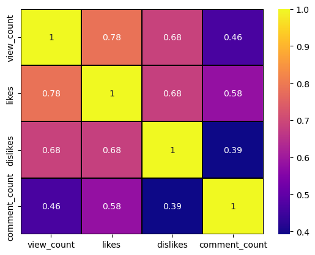

```python
# using seaborn map to find the values with plot:
sns.heatmap(df.corr(),annot=True,cmap="plasma",linewidths=0.1,linecolor="black")
#showing the plotted map using plot.show function:-
plt.show()
#This plot also holds states that it has the positive co-relation of value view_count and dislikes, means when viewcount tends to increase the dislikes also tends to increase.
```

#### This plot also holds states that it has the positive co-relation of value view_count and dislikes, means when viewcount tends to increase the dislikes also tends to increase.

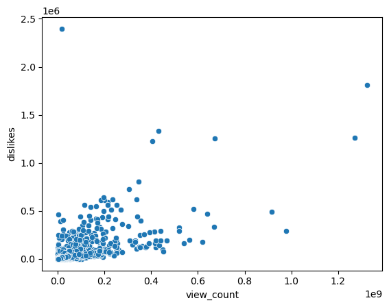

```python
# Also using the scatter plot to demonstrate the relation ship between the dislikes and view_count, this also shows that it has a positive linear relation ship.
sns.scatterplot(data = df,x ="view_count",y ="dislikes")
plt.show()
```

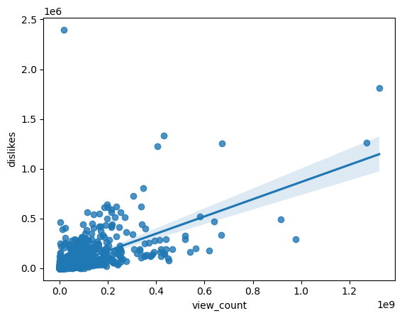

```python
# using the regression plot to showcase the trend line of the scatterplot which was plotted previously:-
sns.regplot(data =df,x="view_count",y="dislikes")
plt.show()
#The trendline clearly states that it has positive corelation...
```

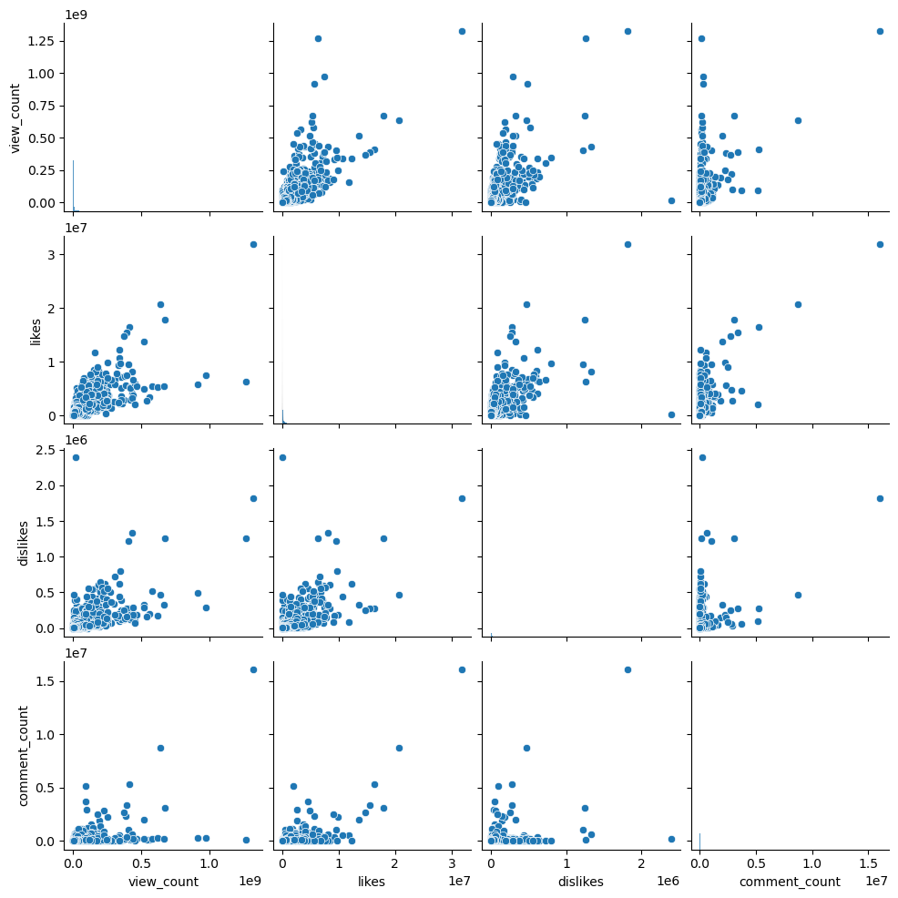

```python
sns.pairplot(df)
plt.show()
```

# 14. Display all the information about the videos that were published in January, and mention the count of videos that were published in January

```python
# using filter function to show case the show the values in data frame:-
df[df["published_month"]=="Jan"]
#This clearly shows that it has about 2099 videos in the shape of rows
```

|  | video_id | title | channel_id | channel_title | published_at | view_count | likes | dislikes | comment_count | tags | description | comments | published_month |
| --- | --- | --- | --- | --- | --- | --- | --- | --- | --- | --- | --- | --- | --- |
| 27 | -2Gwm7QfBnE | Q&A With Naisha | UCYwNMbogQFzMccPSuy-pPWg | MianTwins | 2021-01-21 00:05:47 | 872372 | 38626 | 239 | 621 |  | Hey Guys!!! this has been the most requested v... | I feel like Nate and Aishas personality match ... | Jan |
| 48 | -4sfXSHSxzA | SURPRISING BRENT WITH HIS TIKTOK CRUSH!! | UCPpATKqmMV-CNRNWYaDUwiA | Alexa Rivera | 2021-01-16 21:40:04 | 6504784 | 262477 | 5779 | 7907 |  | He had no idea! Thank you guys so much for wat... | Thank you guys for watching and don't forget t... | Jan |
| 95 | -AJD1Fc5rpQ | WE ARE HAVING A BABY! \| finding out i'm pregna... | UCVsTboAhpnuL6j-tDePvNwQ | Tess Christine | 2021-01-03 21:53:48 | 533084 | 38965 | 119 | 1650 |  | I am so happy to tell you that I am pregnant!!... | Okay I needed a moment to collect my thoughts ... | Jan |
| 103 | -AuJiwjsmWk | Do Ugly Foods Taste Worse? Taste Test | UCzpCc5n9hqiVC7HhPwcIKEg | Good Mythical MORE | 2021-01-19 11:00:01 | 1057077 | 22526 | 531 | 773 | gmm good mythical morning rhettandlink rhett a... | Today, we're doing a blind taste test to deter... | "there's nothing wrong with it being bent"\nI ... | Jan |
| 182 | -JhqO2KWr5U | Schlatt gets fit | UCWZp4y1jqBuvLtiyxSs_ZBw | Big guy | 2021-01-24 22:50:57 | 1724965 | 119431 | 325 | 1578 | jschlatt big guy jschlatt highlights schlatt j... | #jschlatt #schlatt #bigguy #short | Schlatt is single handedly wiping out all the ... | Jan |
| ... | ... | ... | ... | ... | ... | ... | ... | ... | ... | ... | ... | ... | ... |
| 37300 | zmzFL5bG-jc | DEVINE MON PERSONNAGE AVANT AKINATOR ! (c'est ... | UCIlr3byh6wmXgcPx_Tm9Ocw | Piwerre | 2021-01-16 16:12:19 | 670357 | 54462 | 832 | 1249 | Piwerre frere de michou crouton among us devin... | Discord Piwerre : https://discord.gg/QBduPgAA... | Mdr michou quand c'est pas ses tournage il fou... | Jan |
| 37329 | zpzjex7qwrA | Lampard Sacked Within Days Rorys Misery \| Chel... | UCkD-ZOixI0a9FjIExDsHsbg | The Kick Off | 2021-01-03 20:13:49 | 428646 | 12060 | 296 | 1505 | Premier league Chelsea chelsea 1-3 Man City Ch... | The Kick Off watched Manchester City destroy C... | True Its like a fighter who Geordie But I thou... | Jan |
| 37345 | zqyv-B6mnBM | Lil Wayne - Ain't Got Time (Audio) | UCO9zJy7HWrIS3ojB4Lr7Yqw | Lil Wayne | 2021-01-21 05:00:10 | 2238244 | 58925 | 2365 | 5539 | lil wayne weezy weezy wednesday wayne carter y... | Official audio for Lil Wayne "Ain't Got Time",... | RIP Juice Wrld, wrote that on two cups, pour o... | Jan |
| 37383 | zwfu1-24T7Q | PRADA Cup Day 1 \| Full Race Replay \| PRADA Cup... | UCo15ZYO_XDRU9LI30OPtxAg | America's Cup | 2021-01-15 04:07:55 | 317382 | 2008 | 83 | 192 | America's Cup Americas Cup AC36 AC75 Presented... | The opening day of the PRADA Cup in Auckland, ... | Incredible how these boats evolve in a short t... | Jan |
| 37418 | zziBybeSAtw | PELICANS at LAKERS \| FULL GAME HIGHLIGHTS \| Ja... | UCWJ2lWNubArHWmf3FIHbfcQ | NBA | 2021-01-16 05:39:05 | 2841917 | 20759 | 1049 | 2624 | NBA G League Basketball game-0022000187 Lakers... | PELICANS at LAKERS \| FULL GAME HIGHLIGHTS \| Ja... | Montrezl Harrell is going crazy with the rebou... | Jan |

2099 rows × 13 columns

```python
# using for loop to get the count of videos that had been posted in the month of january:-
#initalizing the count to be zero:
count = 0
# using for loop to iterate over the published month:-
for i in df["published_month"]:
#checking if that iterator i which is equal to month Jan:-
    if i=="Jan":
# count will increased if value matches the given criteria:-
        count +=1
print(f"The count of videos which were published in January were about {count} videos")
```

```
The count of videos which were published in January were about 2099 videos
```

```python
# From the len itself it shows the value that it has the 2099 videos published.
len(df[df["published_month"]=="Jan"])
```

```
2099
```